# Empirical Cumulative Distribution Functions in R

[Nathaniel E. Helwig](http://stat.umn.edu/~helwig) Department of Psychology & School of Statistics University of Minnesota

Copyright © January 30, 2026

# 1 Introduction

## 1.1 Motivation and Goals

The *empirical cumulative distribution function* (ECDF) is a simple and powerful nonparametric method for estimating the distribution of an independent and identically distributed (iid) sample of data. In parametric statistical methods, the CDF of the data is typically assumed to follow a particular statistical distribution (e.g., uniform or normal). In contrast, nonparametric statistical methods do not typically assume a particular distribution for the data—instead, nonparametric statistical methods attempt to answer inferential questions for generic distributions, and the ECDF is one tool that is frequently used for this purpose. In these notes, I will provide a brief background on probability density functions (PDFs) and CDFs, introduce the ECDF and its properties, and demonstrate how to apply the ECDF in R and beyond. As we will later see, the ECDF is essential for nonparametric permutation tests and the nonparametric bootstrap.

## 1.2 Probability Density Functions

### 1.2.1 Definition and Properties

Suppose we have some variable $X \sim f(x)$ where $f(x)$ is the *probability density function* (PDF) of $X$.

Note that we have two requirements on $f(x)$:

1. $f(x)\geq 0$ for all $x \in \mathbb{X}$, where $\mathbb{X}$ is the domain of $X$
2. $\int_{\mathbb{X}} f(x) \mathsf{d}x =1$

In R, density functions are obtained using “d” (for density) plus family abbreviation:

- `dunif()` = uniform density
- `dnorm()` = normal density
- `dt()` = Student’s $t$ density

### 1.2.2 Example 1: Uniform Distribution

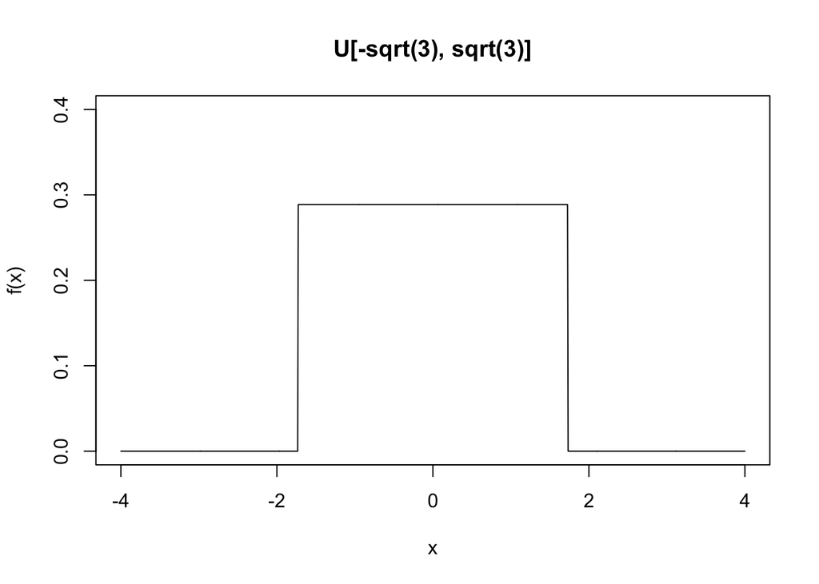

```r
x <- seq(-4, 4, length.out = 1000)
plot(x, dunif(x, -sqrt(3), sqrt(3)), type = "l", xlab = "x", ylab = "f(x)",
     main = "U[-sqrt(3), sqrt(3)]", ylim = c(0, 0.4))
```

### 1.2.3 Example 2: Normal Distribution

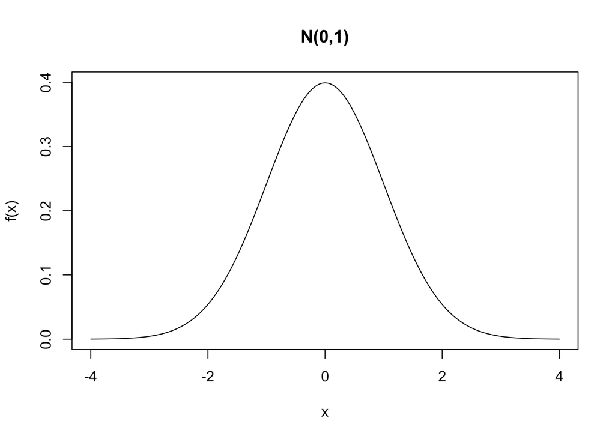

```r
x <- seq(-4, 4, length.out = 1000)
plot(x, dnorm(x), type = "l", xlab = "x", ylab = "f(x)",
     main = "N(0,1)", ylim = c(0, 0.4))
```

### 1.2.4 Example 3: Student’s $t$ Distribution

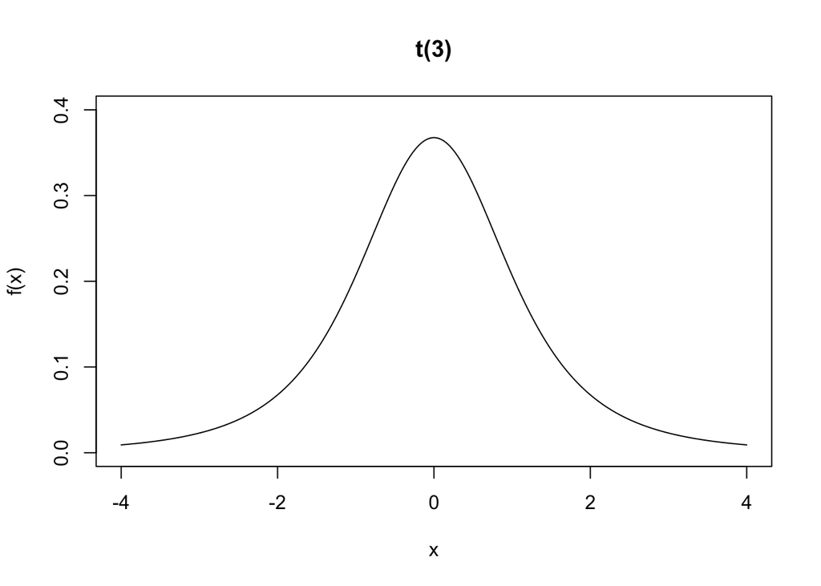

```r
x <- seq(-4, 4, length.out = 1000)
plot(x, dt(x, df = 3), type = "l", xlab = "x", ylab = "f(x)",
     main = "t(3)", ylim = c(0, 0.4))
```

### 1.2.5 Plot All Densities

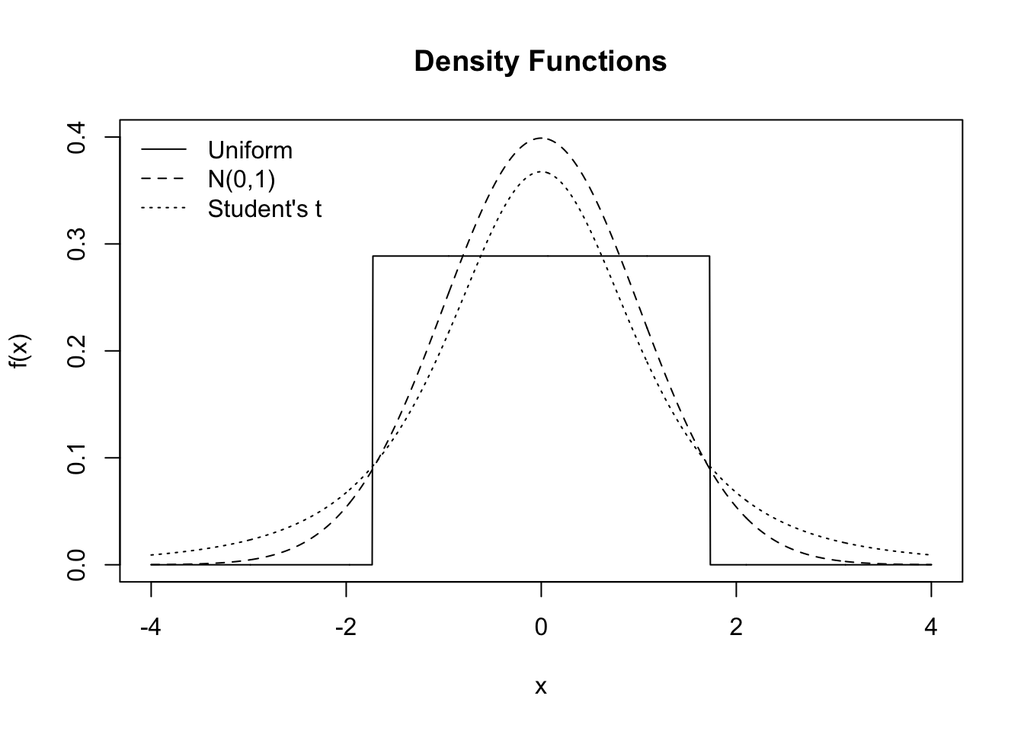

```r
x <- seq(-4, 4, length.out = 1000)
plot(x, dunif(x, -sqrt(3), sqrt(3)), type = "l", xlab = "x", ylab = "f(x)",
     main = "Density Functions", ylim = c(0, 0.4))
lines(x, dnorm(x), lty = 2)
lines(x, dt(x, df = 3), lty = 3)
legend("topleft", c("Uniform", "N(0,1)", "Student's t"), lty = 1:3, bty = "n")
```

## 1.3 Cumulative Distribution Functions

### 1.3.1 Definition and Properties

Probabilities relate to the area under the PDF:
$$P(a\leq X \leq b) = \int_{a}^{b} f(x) \mathsf{d} x = F(b) - F(a)$$
where
$$F(x) = P(X \leq x) = \int_{-\infty}^{x} f(u) \mathsf{d} u$$
is the *cumulative distribution function* (CDF) of the random variable $X$.

Note that we have two requirements on $F(x)$:

1. $0 \leq F(x) \leq 1$ for all $x \in \mathbb{X}$, where $\mathbb{X}$ is the domain of $X$
2. $F(a) \leq F(b)$ for all $a \leq b$

In R, distribution functions are obtained using “p” (for probability) plus family abbreviation:

- `punif()` = uniform probability distribution
- `pnorm()` = normal probability distribution
- `pt()` = Student’s $t$ probability distribution

### 1.3.2 Example 1: Uniform Distribution

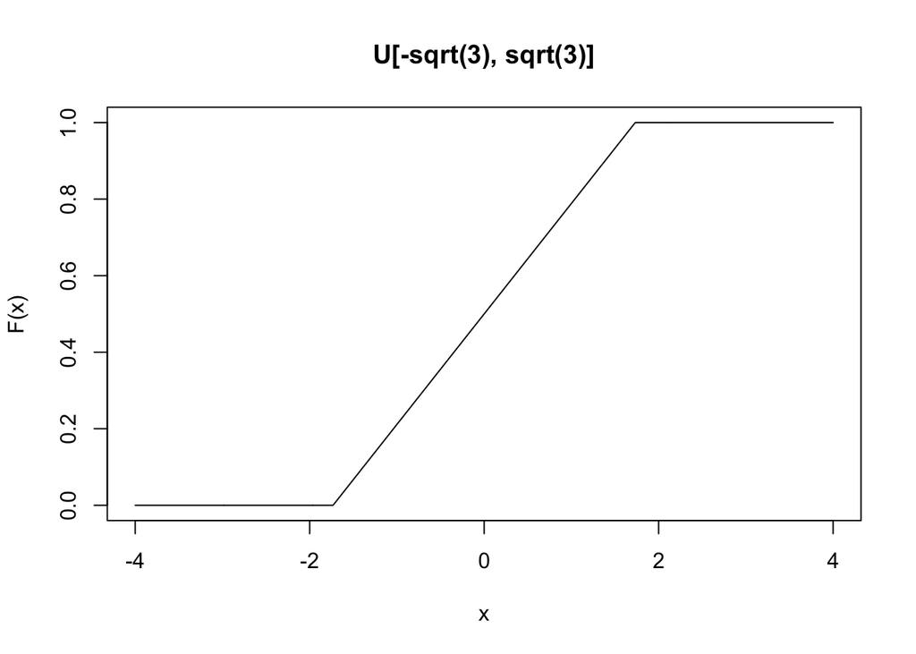

```r
x <- seq(-4, 4, length.out = 1000)
plot(x, punif(x, -sqrt(3), sqrt(3)), type = "l", xlab = "x", ylab = "F(x)",
     main = "U[-sqrt(3), sqrt(3)]", ylim = c(0, 1))
```

### 1.3.3 Example 2: Normal Distribution

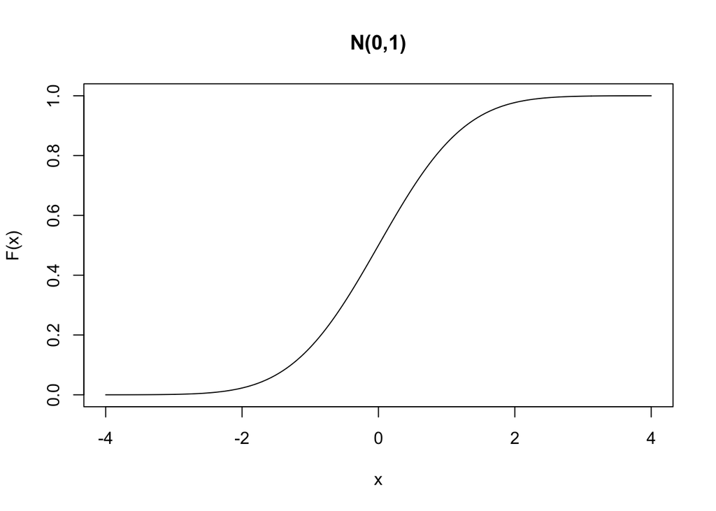

```r
x <- seq(-4, 4, length.out = 1000)
plot(x, pnorm(x), type = "l", xlab = "x", ylab = "F(x)",
     main = "N(0,1)", ylim = c(0, 1))
```

### 1.3.4 Example 3: Student’s $t$ Distribution

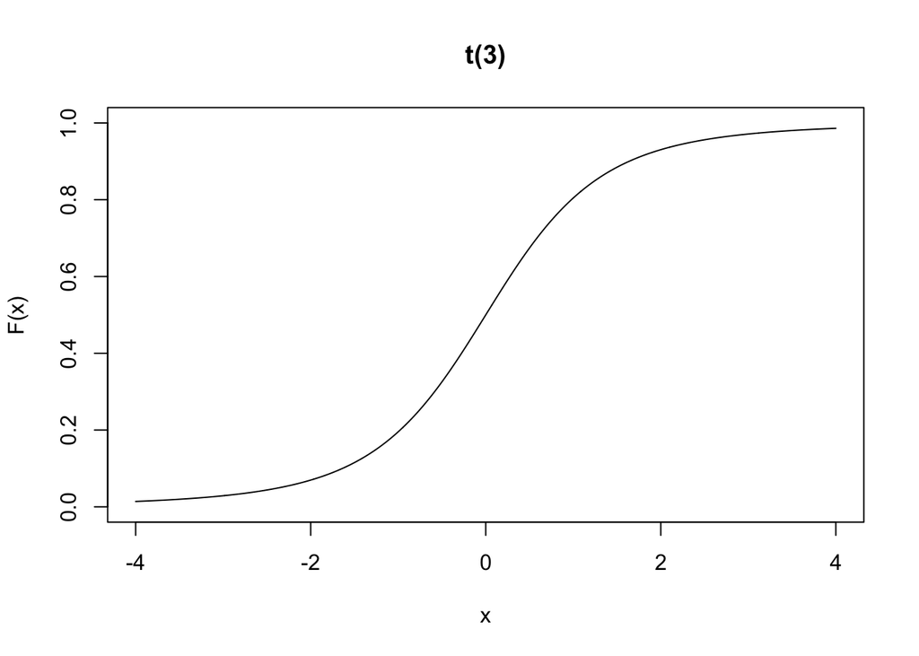

```r
x <- seq(-4, 4, length.out = 1000)
plot(x, pt(x, df = 3), type = "l", xlab = "x", ylab = "F(x)",
     main = "t(3)", ylim = c(0, 1))
```

### 1.3.5 Plot All Distributions

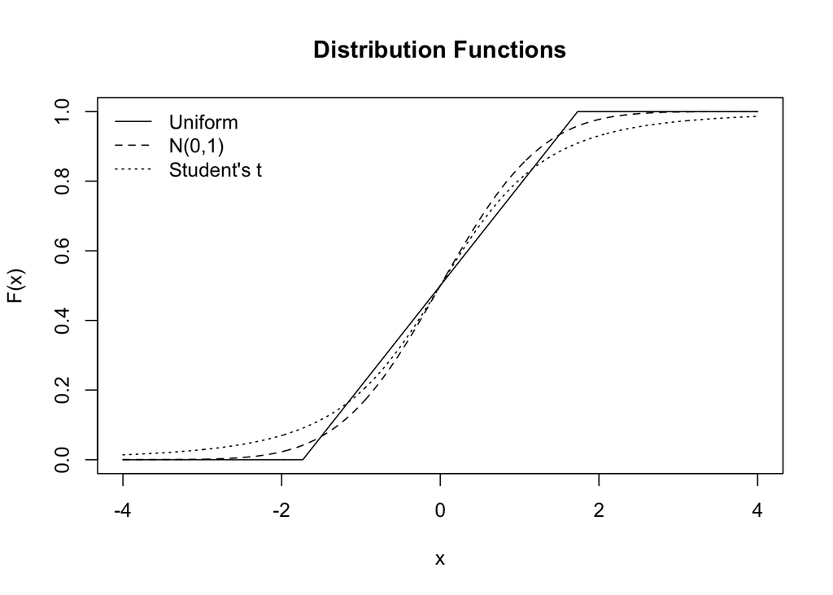

```r
x <- seq(-4, 4, length.out = 1000)
plot(x, punif(x, -sqrt(3), sqrt(3)), type = "l", xlab = "x", ylab = "F(x)",
     main = "Distribution Functions", ylim = c(0, 1))
lines(x, pnorm(x), lty = 2)
lines(x, pt(x, df = 3), lty = 3)
legend("topleft", c("Uniform", "N(0,1)", "Student's t"), lty = 1:3, bty = "n")
```

# 2 Empirical CDF

## 2.1 Definition and Properties

### 2.1.1 Definition

Suppose that $x_i \sim F(x)$ are iid for $i = 1, \ldots, n$, and we want to estimate the CDF $F$.

The *empirical cumulative distribution function (ECDF)* $\hat{F}_n$ is defined as
$$\hat{F}_n(x) = \hat{P}(X \leq x) = \frac{1}{n} \sum_{i=1}^{n} I(x_i \leq
x)$$
where
$$I(x_i \leq x) = \left\{ \begin{matrix} 1 & \mbox{if } x_i \leq x \\
0 & \mbox{otherwise} \end{matrix} \right.$$
denotes an indicator function.

### 2.1.2 Properties

For any fixed value $x$, the ECDF has two important properties

1. $E[\hat{F}_n(x)] = F(x)$
2. $\mathrm{Var}[\hat{F}_n(x)] = \frac{1}{n}F(x)[1-F(x)]$

*Glivenko-Cantelli theorem*: As $n \rightarrow \infty$ we have that
$$\sup_{x \in \mathbb{R}} |\hat{F}_n(x) - F(x)| \rightarrow 0$$
where the convergence is almost surely (i.e., probability goes to one).

## 2.2 Implementation in R

In R, the `ecdf()` function computes ECDFs from an input vector. The returned object is itself a function, which can be used to evaluate the ECDF at any new value.

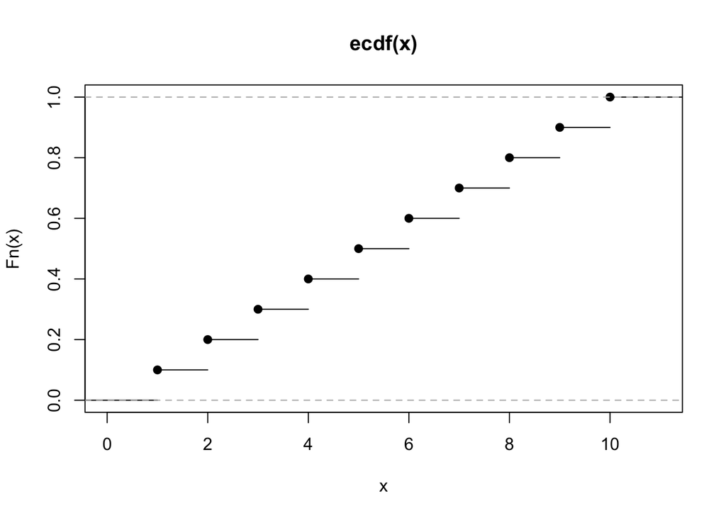

```r
x <- 1:10            # equidistant sequence
Fx <- ecdf(x)        # estimate ECDF
plot(Fx)             # plot ECDF
```

Note that the ECDF is a step function that increases by $1/n = 1/10$ at each observed $x_i$:

```r
Fx(1:10)
```

```
##  [1] 0.1 0.2 0.3 0.4 0.5 0.6 0.7 0.8 0.9 1.0
```

The ECDF evaluates to 0 for any $x < \min_i x_i$

```r
Fx(c(-Inf, -100, 0))
```

```
## [1] 0 0 0
```

and evaluates to 1 for any $x > \max_i x_i$

```r
Fx(c(11, 100, Inf))
```

```
## [1] 1 1 1
```

## 2.3 Multivariate Extensions

The ECDF assigns probability $1/n$ to each value $x_i$, which implies that
$$\hat{P}_n(A) = \frac{1}{n}\sum_{i=1}^n I(x_i \in A)$$
for any set $A$ in the sample space of $X$.

This idea can be easily generalized to situations where $x_i$ is multivariate. In this case, the set $A$ can be defined using any subset of the components of $x_i$. Note that the `ecdf()` function isn’t designed for multivariate data, but ECDF calculations only require logical operators and the `mean()` function.

For example, consider Anderson’s Iris data (made famous by Fisher):

```r
data(iris)
dim(iris)
```

```
## [1] 150   5
```

```r
head(iris)
```

```
##   Sepal.Length Sepal.Width Petal.Length Petal.Width Species
## 1          5.1         3.5          1.4         0.2  setosa
## 2          4.9         3.0          1.4         0.2  setosa
## 3          4.7         3.2          1.3         0.2  setosa
## 4          4.6         3.1          1.5         0.2  setosa
## 5          5.0         3.6          1.4         0.2  setosa
## 6          5.4         3.9          1.7         0.4  setosa
```

Use ECDF to estimate the probability of iris having sepal length greater than 5 cm:

```r
mean(iris$Sepal.Length > 5)
```

```
## [1] 0.7866667
```

Use ECDF to estimate the probability of iris having sepal length greater than 5 cm AND petal length greater than 4 cm:

```r
mean(iris$Sepal.Length > 5 & iris$Petal.Length > 4)
```

```
## [1] 0.5533333
```

Use ECDF to estimate the probability of iris having sepal length greater than 5 cm OR petal length greater than 4 cm:

```r
mean(iris$Sepal.Length > 5 | iris$Petal.Length > 4)
```

```
## [1] 0.7933333
```

Use ECDF to estimate the probability of iris having sepal length to width ratio greater than 2:

```r
mean(iris$Sepal.Length / iris$Sepal.Width > 2)
```

```
## [1] 0.5266667
```

Use ECDF to estimate the probability of iris having sepal length to width ratio greater than 2 AND a petal length to width ratio greater than 3:

```r
Sepal.ratio <- iris$Sepal.Length / iris$Sepal.Width
Petal.ratio <- iris$Petal.Length / iris$Petal.Width
mean(Sepal.ratio > 2 & Petal.ratio > 3)
```

```
## [1] 0.3333333
```

# 3 Examples

## 3.1 Uniform Distribution

Uniform ECDF for different sample sizes:

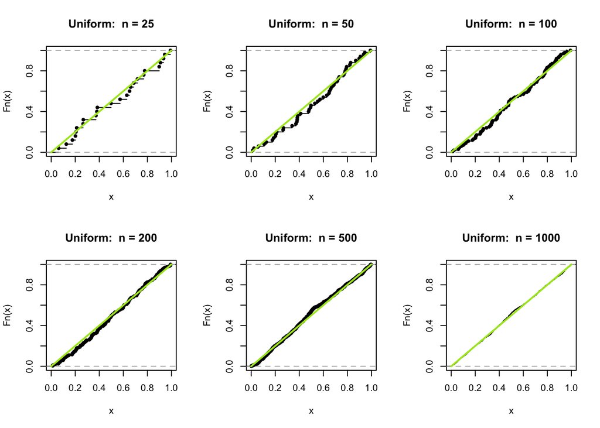

```r
par(mfrow = c(2,3))
xseq <- seq(0, 1, length.out = 1000)
xlim <- c(0, 1)
mda <- "#A8E61D"
for(n in c(25, 50, 100, 200, 500, 1000)){
  set.seed(1)                                     # set random seed
  x <- runif(n)                                   # sample n from U[0,1]
  xmain <- paste("Uniform:  n =", n)              # title for plot
  plot(ecdf(x), xlim = xlim, main = xmain)        # plot ECDF
  lines(xseq, punif(xseq), col = mda, lwd = 2)    # add true CDF
}
```

## 3.2 Normal Distribution

Normal ECDF for different sample sizes:

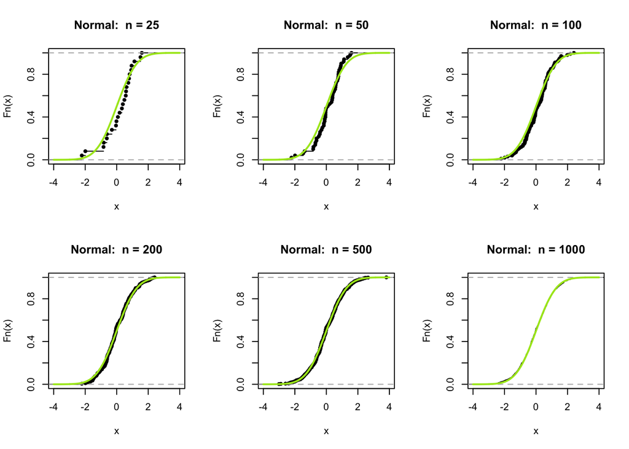

```r
par(mfrow = c(2,3))
xseq <- seq(-4, 4, length.out = 1000)
xlim <- c(-4, 4)
mda <- "#A8E61D"
for(n in c(25, 50, 100, 200, 500, 1000)){
  set.seed(1)                                     # set random seed
  x <- rnorm(n)                                   # sample n from N(0,1)
  xmain <- paste("Normal:  n =", n)               # title for plot
  plot(ecdf(x), xlim = xlim, main = xmain)        # plot ECDF
  lines(xseq, pnorm(xseq), col = mda, lwd = 2)    # add true CDF
}
```

## 3.3 Student’s $t$ Distribution

Student’s $t$ ECDF for different sample sizes:

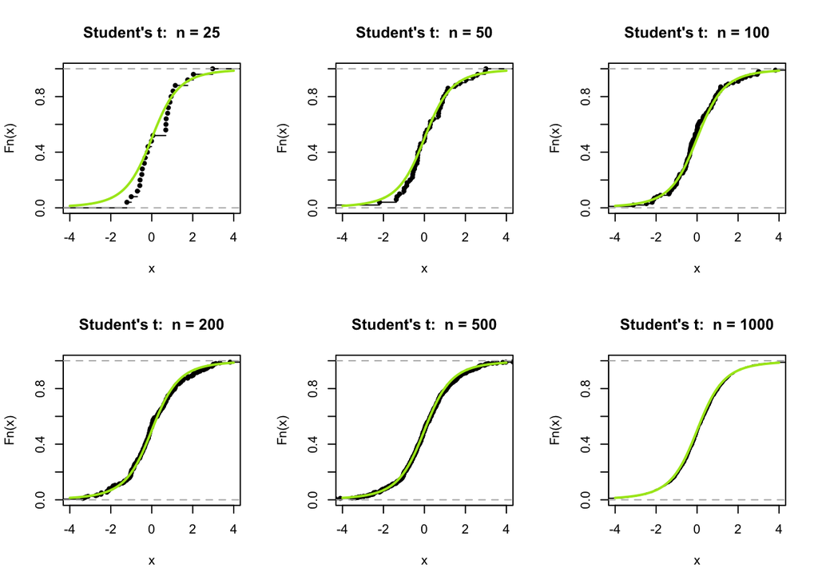

```r
par(mfrow = c(2,3))
xseq <- seq(-4, 4, length.out = 1000)
xlim <- c(-4, 4)
mda <- "#A8E61D"
for(n in c(25, 50, 100, 200, 500, 1000)){
  set.seed(1)                                          # set random seed
  x <- rt(n, df = 3)                                   # sample n from t(3)
  xmain <- paste("Student's t:  n =", n)               # title for plot
  plot(ecdf(x), xlim = xlim, main = xmain)             # plot ECDF
  lines(xseq, pt(xseq, df = 3), col = mda, lwd = 2)    # add true CDF
}
```